# power analysis etc.

Ben Bolker

02 Apr 2019

# experimental design

## the most important thing

> - design your experiment well and execute it well:  
>   you needn’t worry too much in advance about statistics
> - don’t: you’re doomed, statistics can’t save you
> - **randomization**, **control**, **replication**

## randomization

- random *assignment to treatments*
- poorer alternative: *haphazard* assignment
- stratification  
  (i.e., randomize within groups)
- related: experimental *blinding*

## control

- maximize *desired* variation
  - e.g. large doses (tradeoff with biological realism)
- minimize *undesired* variation
  - within-subjects designs
    - e.g. paired, randomized-block, crossover
  - reduce environmental variation
    - tradeoff with generality
    - e.g. environmental chambers, inbred/clones
- isolate desired effects: **positive/negative controls**  
  (vehicle-only, cage treatments, etc.)
- measure/control for covariates

## Hurlbert (1984) Table 1

| Source of confusion | Features of an experimental design that reduce or eliminate confusion |
| --- | --- |
| Temporal change | Control treatments |
| Procedure effects | Control treatments |
| Experimenter bias | Randomized assignment of experimental units to treatments Randomization in conduct of other procedures “Blind” procedures* |
| Experimenter-generated variability (random error) | Replication of treatments |
| Initial or inherent variability among experimental units | Replication of treatments Interspersion of treatments Concomitant observations |
| Nondemonic intrusion | Replication of treatments Interspersion of treatments |
| Demonic intrusion | Eternal vigilance, exorcism, human sacrifices, etc. |

## replication

> - how big does your experiment need to be?
> - **power**: probability of detecting an effect of a particular size,  
>   if one exists
> - more generally: how much information? what kinds of mistakes? (Gelman and Carlin 2014)
> - *underpowered* studies - failure is likely - cheating is likely - *significance filter* $\to$ biased estimates
> - *overpowered* studies waste time, lives, $
> - **pseudoreplication** (Hurlbert 1984; Davies and Gray 2015) confounding sampling units with treatment units

# power analysis

## definition

- **power** is the probability of successfully rejecting the null hypothesis
  - i.e., being able to see something clearly
- depends on
  - biological effect size
  - noise level
  - experimental design (sample size + …)
- uses null-effect *counterfactual*

## power analysis: a cautionary conversation

[an introductory video](https://www.youtube.com/watch?v=PbODigCZqL8&feature=youtu.be)

## where do effect sizes come from?

**if you can’t guess an effect size you shouldn’t be doing an experiment**

## power analysis: methods

- seat-of-the-pants (“ask your supervisor”)
- [web calculators](http://homepage.stat.uiowa.edu/~rlenth/Power/) (Lenth 2006)
- [G*Power](http://www.gpower.hhu.de/) (Faul et al. 2009)

## methods, cont.: power analysis in R

```r
apropos("^power\\.")  ## base-R functions
```

```
## [1] "power.anova.test" "power.prop.test"  "power.t.test"
```

```r
a1 <- available.packages(repos="https://cran.rstudio.com")
pow_pkgs <- grep("power",rownames(a1),value=TRUE,ignore.case=TRUE)
head(pow_pkgs, 10)
```

```
##  [1] "bivarRIpower"       "clusterPower"       "CoRpower"
##  [4] "easypower"          "LindleyPowerSeries" "longpower"
##  [7] "LPower"             "mthapower"          "nasapower"
## [10] "PoweR"
```

## the `pwr` package

```r
library("pwr")
apropos("^pwr")
```

```
##  [1] "pwr.2p.test"    "pwr.2p2n.test"  "pwr.anova.test" "pwr.chisq.test"
##  [5] "pwr.f2.test"    "pwr.norm.test"  "pwr.p.test"     "pwr.r.test"
##  [9] "pwr.t.test"     "pwr.t2n.test"
```

also: `library("sos"); findFn("{power analysis}")`

## ant example

```r
dd <- read.csv("data/ants.csv")
power.t.test(n=c(10,10),delta=2,sd=1)
power.t.test(power=0.8,delta=2,sd=1)
```

[output not shown]

## power curves

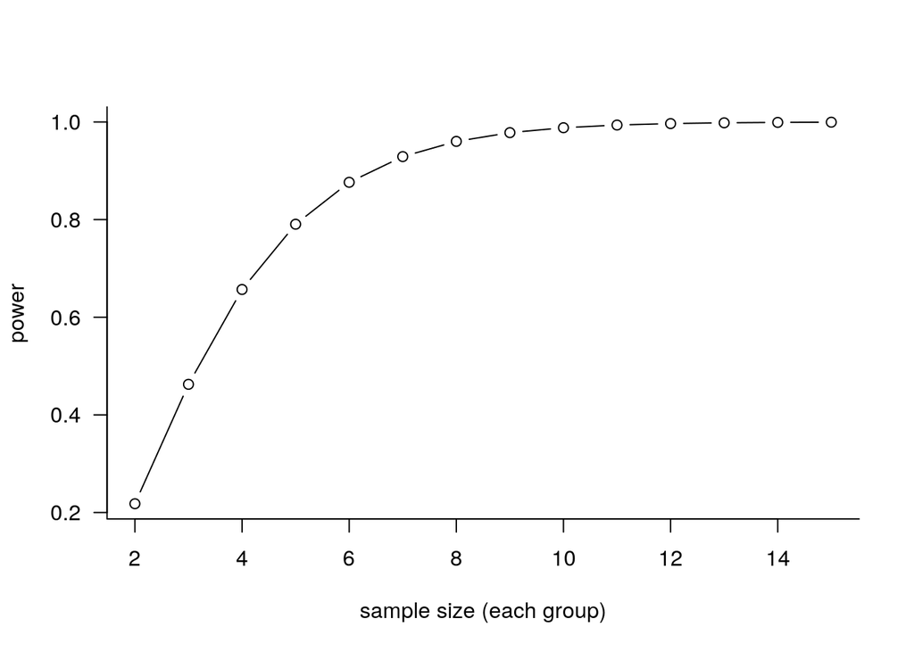

```r
nvec <- 2:15
powfun <- function(n) {
   power.t.test(n, delta=2, sd=1)$power
}
powvec <- sapply(nvec,powfun)
par(las=1,bty="l")
plot(nvec,powvec,type="b", xlab="sample size (each group)",
     ylab="power")
```

## avoid: scaled effect sizes

- e.g. Cohen’s $d$/$g$
- scaling *not* by standard deviation of a predictor, but by the noise
- removes units (and biological meaning)
- refers only to *clarity*, not *biological impact*
- if you need these for input to a program, start with biological effects and translate

## avoid: “T-shirt” effect sizes

- Cohen proposed standardized “small”, “medium”, and “large” scaled effect sizes
- convenient: but scaled/unitless/non-biological!

From [Russ Lenth FAQs](http://homepage.stat.uiowa.edu/~rlenth/Power/#frequently-asked-questions):

> for a “medium” effect size, you’ll choose the same $n$ regardless of the accuracy or reliability of your instrument, or the narrowness or diversity of your subjects

## avoid: retrospective power analysis

- running
- tautological: high $p$-value $\leftrightarrow$ low power
- essentially useless
- instead:
  - show confidence intervals
  - (*if necessary*) pretend you’re doing prospective analysis
- push back: Thomas (1997), Gerard, Smith, and Weerakkody (1998), Hoenig and Heisey (2001)

## what to do about bad news?

- simplify the question
- use simpler designs (e.g. low/high vs continuous range)
- push treatments harder
- ask a different question

## what if your analysis is more complex?

- simplify
- simulate
  - see [chap 5](https://ms.mcmaster.ca/~bolker/emdbook/chap5A.pdf) (Bolker 2008)
  - much more flexible - e.g. simulate effects of lack of balance - endpoints other than power (e.g. CV)

## simulation (linear regression example)

```r
## experimental design
N <- 20; x_min <- 0; x_max <- 2
x <- runif(N, min=x_min, max=x_max)
## model world
a <- 2; b <- 1; sd_y <- 1
## setup
nsim <- 1000; pval <- numeric(N); set.seed(101)
for (i in 1:nsim) {
  y_det <- a + b * x  ## deterministic y
  y <- rnorm(N, mean = y_det, sd = sd_y)
  m <- lm(y ~ x)
  pval[i] <- coef(summary(m))["x", "Pr(>|t|)"] ## extract p-value
}
mean(pval<0.05)
```

```
## [1] 0.643
```

## references

Bolker, Benjamin M. 2008. *Ecological Models and Data in R*. Princeton University Press.

Davies, G. Matt, and Alan Gray. 2015. “Don’t Let Spurious Accusations of Pseudoreplication Limit Our Ability to Learn from Natural Experiments (and Other Messy Kinds of Ecological Monitoring).” *Ecology and Evolution*, October. https://doi.org/10.1002/ece3.1782.

Faul, Franz, Edgar Erdfelder, Axel Buchner, and Albert-Georg Lang. 2009. “Statistical Power Analyses Using G*Power 3.1: Tests for Correlation and Regression Analyses.” *Behavior Research Methods* 41 (4): 1149–60. https://doi.org/10.3758/BRM.41.4.1149.

Gelman, Andrew, and John Carlin. 2014. “Beyond Power Calculations: Assessing Type S (Sign) and Type M (Magnitude) Errors.” *Perspectives on Psychological Science* 9 (6): 641–51. https://doi.org/10.1177/1745691614551642.

Gerard, Patrick D., David R. Smith, and Govinda Weerakkody. 1998. “Limits of Retrospective Power Analysis.” *The Journal of Wildlife Management* 62 (2): 801–7. http://www.jstor.org/stable/3802357.

Hoenig, John M., and Dennis M. Heisey. 2001. “The Abuse of Power.” *The American Statistician* 55 (1): 19–24. https://doi.org/10.1198/000313001300339897.

Hurlbert, Stuart H. 1984. “Pseudoreplication and the Design of Ecological Field Experiments.” *Ecological Monographs* 54 (2): 187–211. https://doi.org/10.2307/1942661.

Lenth, R. V. 2006. “Java Applets for Power and Sample Size [Computer Software].” http://www.stat.uiowa.edu/~rlenth/Power.

Thomas, Len. 1997. “Retrospective Power Analysis.” *Conservation Biology* 11 (1): 276–80. https://doi.org/10.1046/j.1523-1739.1997.96102.x.